# Tarea 6: Solución numérica a EDOs y EDPs

## Iker Bali Elizalde A01656437

1. Estudiemos la EDO conocida como 'problema de prueba' en la teoría de estabilidad de métodos numéricos:

   $\frac{dx}{dt}=-\lambda x, \lambda>0 \\ x(0)=x_0$

1.1. Escribe la solución analítica y bosquéjala para $x_0 > 0$

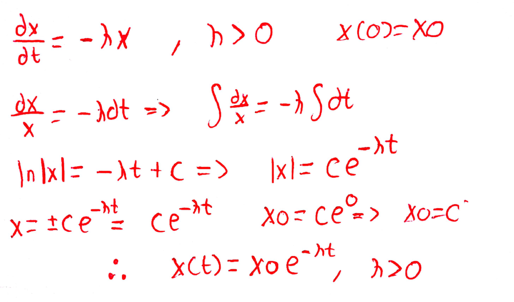

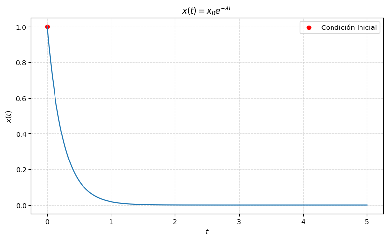

```python
import numpy as np
import matplotlib.pyplot as plt


x0 = 1
lm = 4
t = np.linspace(0, 5, 1000)
x = x0 * np.exp(- lm* t)
plt.figure(figsize=(8, 5))
plt.plot(t, x)
plt.scatter(0,x0,label="Condición Inicial",color="red")
plt.xlabel('$t$')
plt.ylabel('$x(t)$')
plt.title(r'$x(t) = x_0 e^{- \lambda t}$')
plt.grid(True, color='silver', linestyle='--', alpha=0.5)
plt.legend()

plt.tight_layout()
plt.show()
```

1.2. Escribe las soluciones numéricas utilizando los tres métodos que vimos. Usa N pasos de tamaño h. Recuerda que debes empezar con la relación de recurrencia de cada método. En este caso lineal, debes ser capaz de escribir la expresión cerrada.

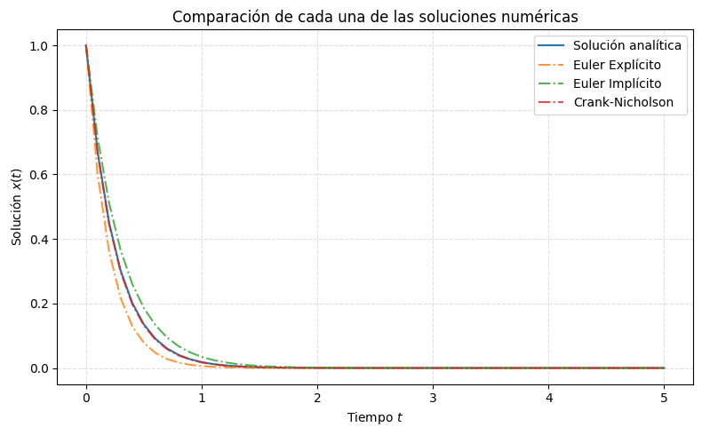

```python
N = 50
h = 0.1
t = np.linspace(0, N*h, N+1)


x = x0 * np.exp(- lm * t)


m_eulerExp = np.zeros(N+1)
m_eulerExp[0] = x0

for n in range(N):
    m_eulerExp[n+1] = m_eulerExp[n] * (1 - h * lm)


m_eulerImp = np.zeros(N+1)
m_eulerImp[0] = x0

for n in range(N):
    m_eulerImp[n+1] = m_eulerImp[n] / (1 + h * lm)


m_crankNic = np.zeros(N+1)
m_crankNic[0] = x0
for n in range(N):
    m_crankNic[n+1] = m_crankNic[n] * (1 - h * lm / 2) / (1 + h * lm / 2)

plt.figure(figsize=(8, 5))

plt.plot(t, x, label='Solución analítica')
plt.plot(t, m_eulerExp, linestyle='dashdot', alpha=0.8, label='Euler Explícito')
plt.plot(t, m_eulerImp, linestyle='dashdot', alpha=0.8, label='Euler Implícito')
plt.plot(t, m_crankNic, linestyle='dashdot', alpha=0.8, label='Crank-Nicholson')

plt.xlabel('Tiempo $t$')
plt.ylabel('Solución $x(t)$')
plt.title('Comparación de cada una de las soluciones numéricas')

plt.grid(True, color='silver', linestyle='--', alpha=0.5)
plt.legend()

plt.tight_layout()
plt.show()
```

1.3. Utiliza las expresiones cerradas obtenidas anteriormente para encontrar el umbral estable para el tamaño de paso.

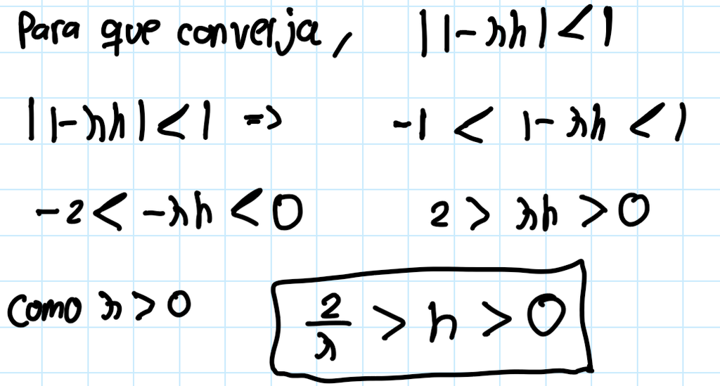

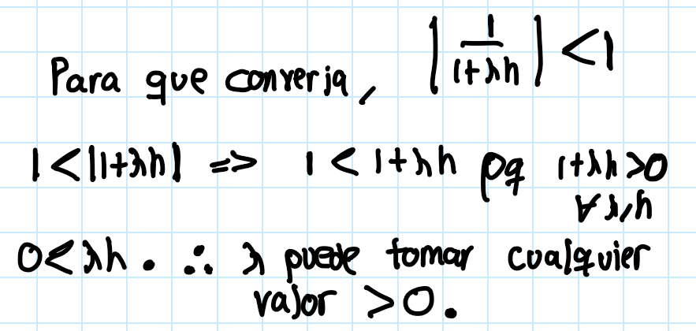

Jack Nicholson

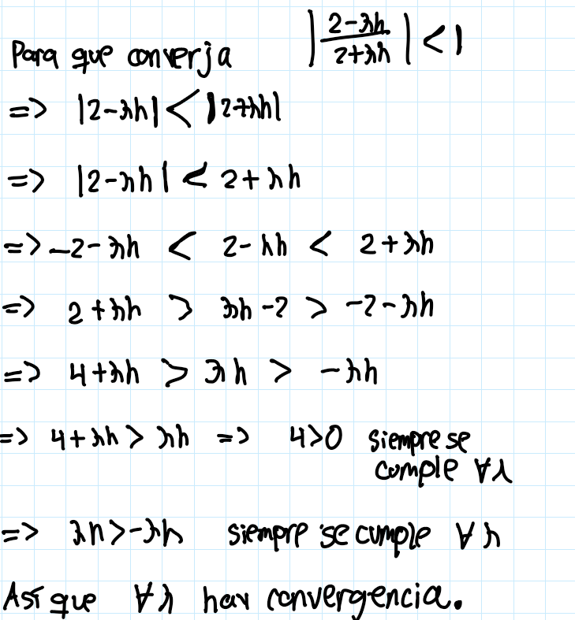

1.4. Sea $λ=5$ y $x_0=10$. Implementa los métodos para $0≤t≤10$ con los siguientes tamaños de paso: $h=[0.1,0.2,.03,0.4,0.5,0.75,1]$. Grafica las soluciones numéricas al igual que la analítica. ¿Qué observas? ¿Cómo se relaciona con tu análisis de estabilidad?

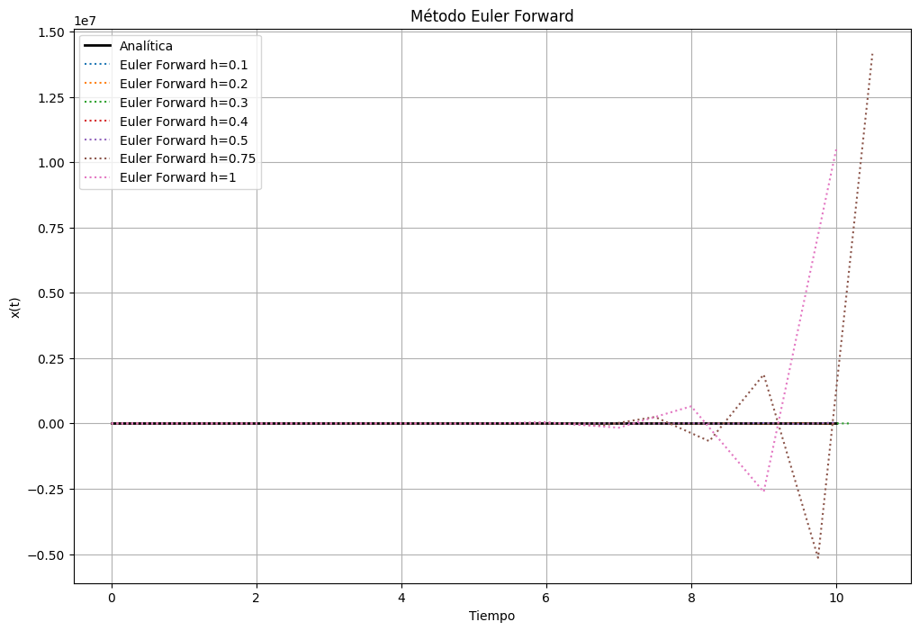

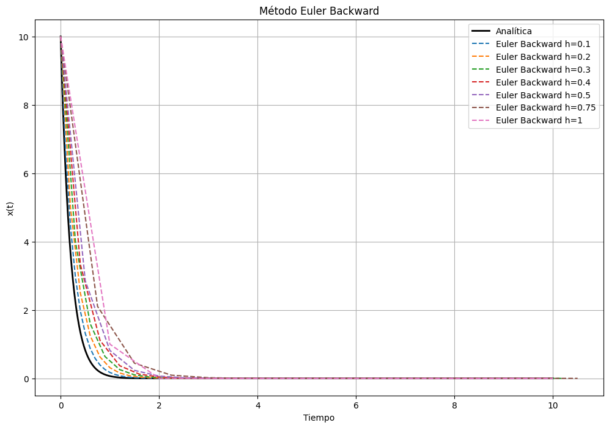

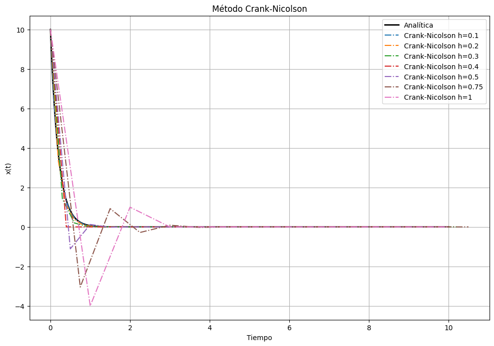

```python
import numpy as np
import matplotlib.pyplot as plt

# Parámetros
lambda_ = 5
x0 = 10
t0 = 0
tf = 10

# Solución analítica
def x_analitica(t):
    return x0 * np.exp(-lambda_ * t)

# Euler Forward
def euler_forward(h):
    t = np.arange(t0, tf+h, h)
    x = np.zeros_like(t)
    x[0] = x0
    for n in range(1, len(t)):
        x[n] = x[n-1] - h * lambda_ * x[n-1]
    return t, x

# Euler Backward
def euler_backward(h):
    t = np.arange(t0, tf+h, h)
    x = np.zeros_like(t)
    x[0] = x0
    for n in range(1, len(t)):
        x[n] = x[n-1] / (1 + h * lambda_)
    return t, x

# Crank-Nicolson
def crank_nicolson(h):
    t = np.arange(t0, tf+h, h)
    x = np.zeros_like(t)
    x[0] = x0
    for n in range(1, len(t)):
        x[n] = x[n-1] * (1 - 0.5 * h * lambda_) / (1 + 0.5 * h * lambda_)
    return t, x

# Tamaños de paso
h_values = [0.1, 0.2, 0.3, 0.4, 0.5, 0.75, 1]

# Graficar soluciones para Euler Forward
plt.figure(figsize=(12, 8))
t_analitico = np.linspace(t0, tf, 400)
x_analitico = x_analitica(t_analitico)
plt.plot(t_analitico, x_analitico, label='Analítica', color='black', linewidth=2)

for h in h_values:
    t_ef, x_ef = euler_forward(h)
    plt.plot(t_ef, x_ef, label=f'Euler Forward h={h}', linestyle='dotted')

plt.xlabel('Tiempo')
plt.ylabel('x(t)')
plt.title('Método Euler Forward')
plt.legend()
plt.grid(True)
plt.show()

# Graficar soluciones para Euler Backward
plt.figure(figsize=(12, 8))
t_analitico = np.linspace(t0, tf, 400)
x_analitico = x_analitica(t_analitico)
plt.plot(t_analitico, x_analitico, label='Analítica', color='black', linewidth=2)

for h in h_values:
    t_eb, x_eb = euler_backward(h)
    plt.plot(t_eb, x_eb, label=f'Euler Backward h={h}', linestyle='dashed')

plt.xlabel('Tiempo')
plt.ylabel('x(t)')
plt.title('Método Euler Backward')
plt.legend()
plt.grid(True)
plt.show()

# Graficar soluciones para Crank-Nicolson
plt.figure(figsize=(12, 8))
t_analitico = np.linspace(t0, tf, 400)
x_analitico = x_analitica(t_analitico)
plt.plot(t_analitico, x_analitico, label='Analítica', color='black', linewidth=2)

for h in h_values:
    t_cn, x_cn = crank_nicolson(h)
    plt.plot(t_cn, x_cn, label=f'Crank-Nicolson h={h}', linestyle='dashdot')

plt.xlabel('Tiempo')
plt.ylabel('x(t)')
plt.title('Método Crank-Nicolson')
plt.legend()
plt.grid(True)
plt.show()
```

2. Considera la EDO. $\frac{dx}{dt} =-kx^2, x(0)=x_0, k>0$

2.1. Encuentra la solución analítica.

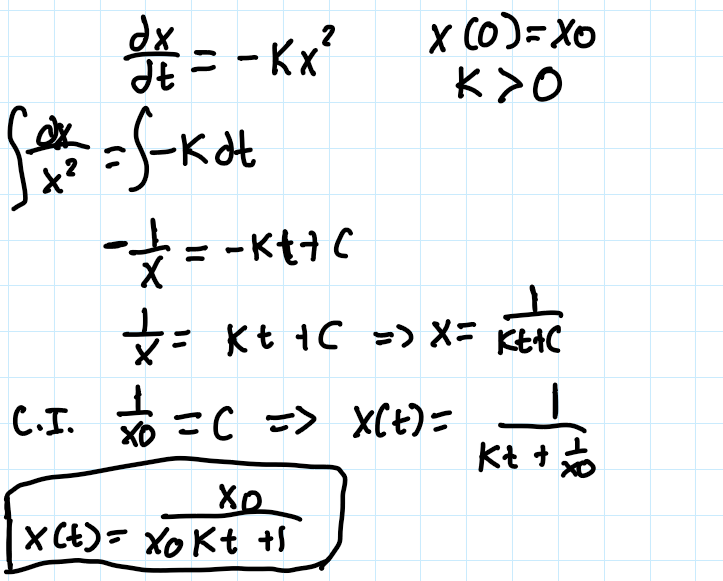

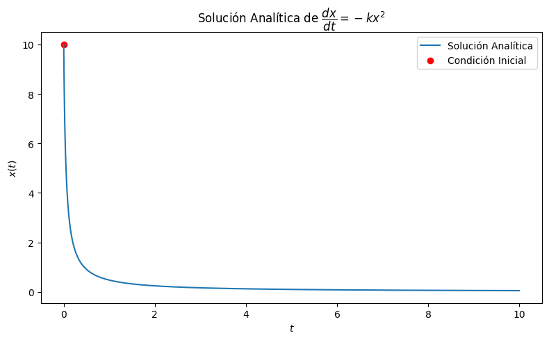

```python
# parámetros iniciales
x0 = 10
k = 2
t = np.linspace(0, 10, 1000)


def solAnalitica_edo2(t, x0, k):
    return x0 / ((k * t * x0) + 1)


x = solAnalitica_edo2(t, x0, k)
plt.figure(figsize=(8, 5))
plt.plot(t, x, label='Solución Analítica')
plt.xlabel('$t$')
plt.ylabel('$x(t)$')
plt.scatter(0,x0,label="Condición Inicial",color="red")
plt.title('Solución Analítica de $\dfrac{dx}{dt} = -kx^2$')
plt.legend()

plt.tight_layout()
plt.show()
```

2.2. Escribe la relación de recurrencia para los 3 métodos numéricos. Desafortunadamente, en este caso no podemos encontrar una solución cerrada de 0 a N directamente, así que los umbrales de estabilidad no son claros.

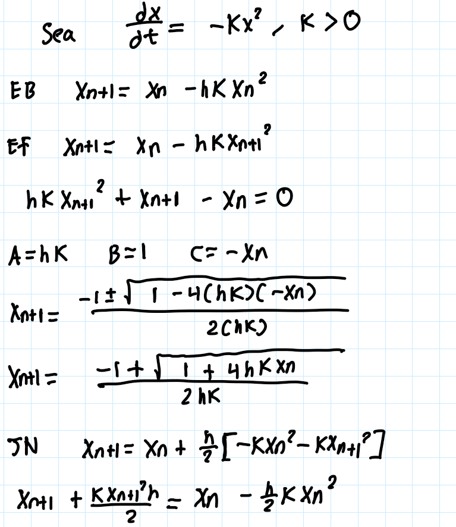

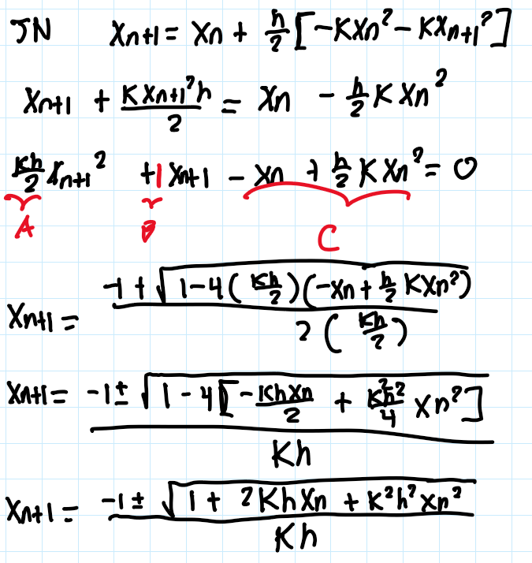

2.3. Resuelve numéricamente la EDO con los 3 métodos en $0≤t≤10$ usando los siguientes parámetros:

$k=[1,2,5,10] $

$h=[0.1,0.2,\cdots,1]$

Compara las soluciones numéricas de cada método (con cada combinación de parámetros) con la solución analítica. Tu decide como mostrar los resultados: gráficas de línea, gráficas de mosaico, etc.

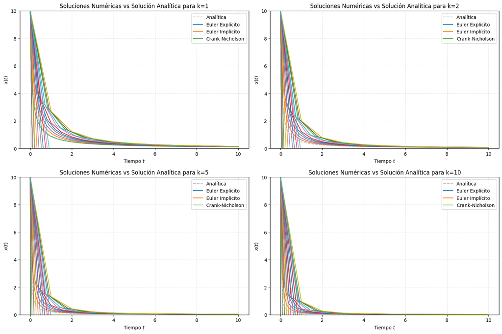

```python
import numpy as np
import matplotlib.pyplot as plt

def euler_explicito(x0, h, k, N):
    x = np.zeros(N+1)
    x[0] = x0

    for n in range(N):
        x[n+1] = x[n] - h*k*x[n]**2

    return x

def euler_implicito(x0, h, k, N):
    x = np.zeros(N+1)
    x[0] = x0

    for n in range(N):
        a = h*k
        b = 1
        c = -x[n]
        discriminant = b**2 - 4*a*c

        if discriminant >= 0:
            x[n+1] = (-b + np.sqrt(discriminant)) / (2*a)
        else:
            x[n+1] = (-b) / (2*a)

    return x

def crank_nicholson(x0, h, k, N):
    x = np.zeros(N+1)
    x[0] = x0

    for n in range(N):
        a = h*k/2
        b = 1
        c = -(x[n] - h*k/2*x[n]**2)
        discriminant = b**2 - 4*a*c

        if discriminant >= 0:
            x[n+1] = (-b + np.sqrt(discriminant)) / (2*a)
        else:
            x[n+1] = (-b) / (2*a)

    return x

k_vals = [1, 2, 5, 10]
h_vals = np.arange(0.1, 1.1, 0.1)
t_final = 10
x0 = 10

plt.figure(figsize=(15, 10))

for i, k in enumerate(k_vals):
    plt.subplot(2, 2, i+1)

    for j, h in enumerate(h_vals):
        N = int(t_final / h)
        t = np.linspace(0, t_final, N+1)

        x_analitico = solAnalitica_edo2(t, x0, k)
        x_eulerEXP = euler_explicito(x0, h, k, N)
        x_eulerIMP = euler_implicito(x0, h, k, N)
        x_crankNIC = crank_nicholson(x0, h, k, N)

        if j == 0:
            plt.plot(t, x_analitico, color='silver', linestyle='--', label='Analítica')

        plt.plot(t, x_eulerEXP, label=f'Euler Explícito' if j == 0 else '')
        plt.plot(t, x_eulerIMP,  label=f'Euler Implícito' if j == 0 else '')
        plt.plot(t, x_crankNIC,  alpha=0.8, label=f'Crank-Nicholson' if j == 0 else '')

    plt.xlabel('Tiempo $t$')
    plt.ylabel('$x(t)$')
    plt.title(f'Soluciones Numéricas vs Solución Analítica para k={k}')
    plt.grid(True, color='silver', linestyle='--', alpha=0.5)
    plt.ylim([0,10])
    plt.legend()

plt.tight_layout()
plt.show()
```

3. Subamos a 2 dimensiones. Considera la ecuación vectorial:

$\frac{d\mathbf{x}}{dt}=\mathbf{Fx}, \mathbf{x}(0)=\mathbf{x}_0$

Donde $\mathbf{F}=\begin{bmatrix} 0 & 1 \\ -1 & 0 \end{bmatrix}$ $\mathbf{x}_0 = \begin{bmatrix} 2 \\ 0 \end{bmatrix}$

3.1. Escribe la solución analítica y describe la trayectoria en el espacio de fase.

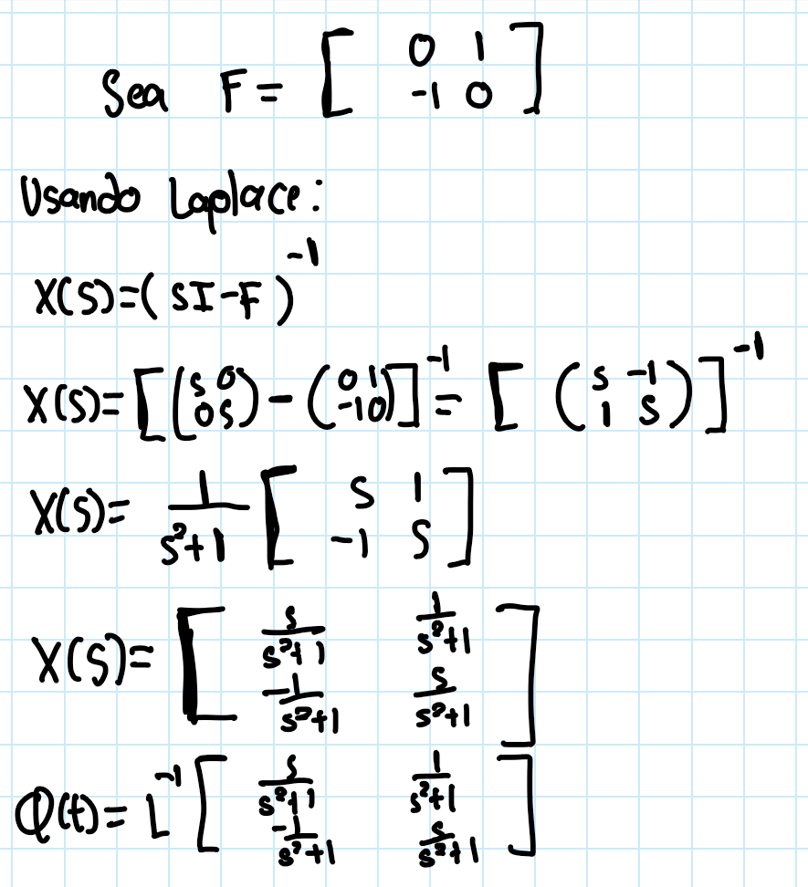

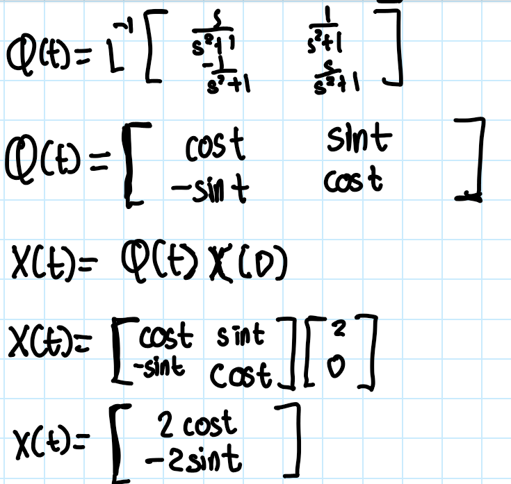

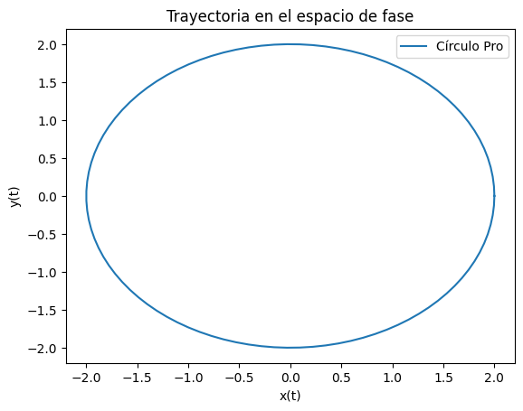

```python
plt.title("Trayectoria en el espacio de fase")
t=np.linspace(0,2*np.pi,100)
x=2*np.cos(t)
y=-2*np.sin(t)
plt.plot(x,y,label="Círculo Pro")
plt.xlabel("x(t)")
plt.ylabel("y(t)")
plt.legend()
plt.show()
```

3.2. Resuelve numéricamente la EDO con los 2 métodos de Euler en $0≤t≤10$ usando los siguientes tamaños de paso: $h=[0.1,0.5,1]$. Despliega los resultados numéricos (muestra tanto la evolución de las variables con respecto al tiempo así como la trayectoria en el espacio de fase) y compara con el resultado analítico. En este caso, el método implícito puede complicarse (pero sólo un poco)

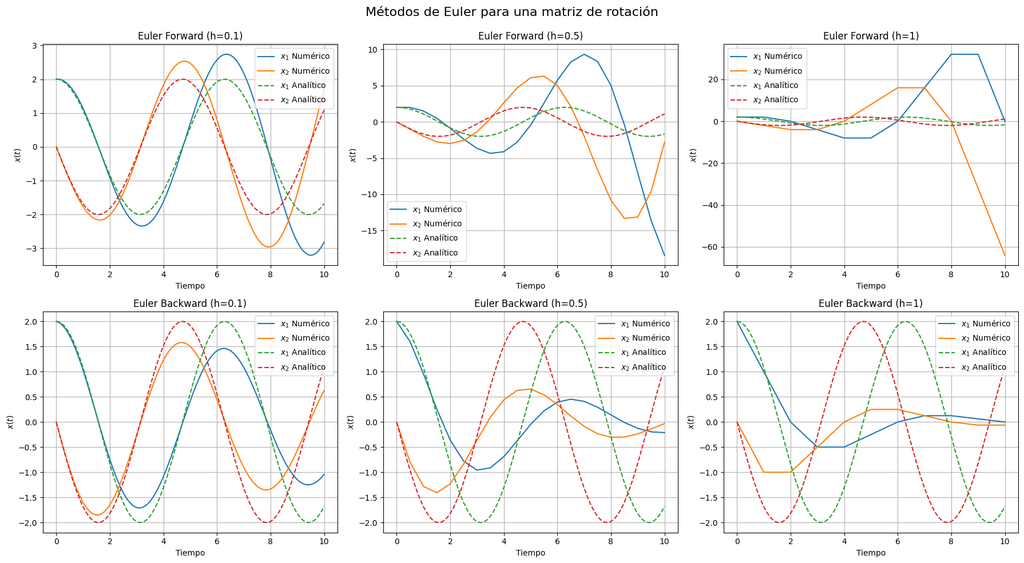

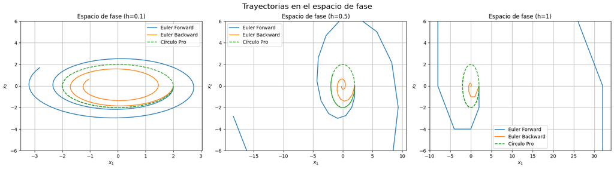

```python
import numpy as np
import matplotlib.pyplot as plt

# Parámetros iniciales
x0 = np.array([2, 0])
F = np.array([[0, 1], [-1, 0]])
t0 = 0
tf = 10

# Tamaños de paso
h_values = [0.1, 0.5, 1]

# Solución analítica
def x_analitica(t):
    return np.array([2 * np.cos(t), -2 * np.sin(t)])

# Método de Euler Forward
def euler_forward(F, x0, h, t0, tf):
    t = np.arange(t0, tf + h, h)
    x = np.zeros((len(t), len(x0)))
    x[0, :] = x0
    for n in range(1, len(t)):
        x[n, :] = x[n-1, :] + h * F.dot(x[n-1, :])
    return t, x

# Método de Euler Backward
def euler_backward(F, x0, h, t0, tf):
    t = np.arange(t0, tf + h, h)
    x = np.zeros((len(t), len(x0)))
    x[0, :] = x0
    I = np.eye(len(x0))
    for n in range(1, len(t)):
        x[n, :] = np.linalg.solve(I - h * F, x[n-1, :])
    return t, x

# Graficar evolución temporal
fig, axs = plt.subplots(2, 3, figsize=(18, 10))

for idx, h in enumerate(h_values):
    # Solución analítica
    t_analitico = np.linspace(t0, tf, 400)
    x_analitico = x_analitica(t_analitico)

    # Euler Forward
    t_ef, x_ef = euler_forward(F, x0, h, t0, tf)

    # Euler Backward
    t_eb, x_eb = euler_backward(F, x0, h, t0, tf)

    # Graficar Euler Forward
    axs[0, idx].plot(t_ef, x_ef[:, 0], label='$x_1$ Numérico')
    axs[0, idx].plot(t_ef, x_ef[:, 1], label='$x_2$ Numérico')
    axs[0, idx].plot(t_analitico, x_analitico[0, :], '--', label='$x_1$ Analítico')
    axs[0, idx].plot(t_analitico, x_analitico[1, :], '--', label='$x_2$ Analítico')
    axs[0, idx].set_title(f'Euler Forward (h={h})')
    axs[0, idx].set_xlabel('Tiempo')
    axs[0, idx].set_ylabel('$x(t)$')
    axs[0, idx].legend()
    axs[0, idx].grid(True)

    # Graficar Euler Backward
    axs[1, idx].plot(t_eb, x_eb[:, 0], label='$x_1$ Numérico')
    axs[1, idx].plot(t_eb, x_eb[:, 1], label='$x_2$ Numérico')
    axs[1, idx].plot(t_analitico, x_analitico[0, :], '--', label='$x_1$ Analítico')
    axs[1, idx].plot(t_analitico, x_analitico[1, :], '--', label='$x_2$ Analítico')
    axs[1, idx].set_title(f'Euler Backward (h={h})')
    axs[1, idx].set_xlabel('Tiempo')
    axs[1, idx].set_ylabel('$x(t)$')
    axs[1, idx].legend()
    axs[1, idx].grid(True)

plt.tight_layout(rect=[0, 0, 1, 0.95])
plt.suptitle('Métodos de Euler para una matriz de rotación', fontsize=16)
plt.show()

# Graficar espacio de fase
fig, axs = plt.subplots(1, 3, figsize=(18, 5))

for idx, h in enumerate(h_values):
    # Solución analítica
    t_analitico = np.linspace(t0, tf, 400)
    x_analitico = x_analitica(t_analitico)

    # Euler Forward
    t_ef, x_ef = euler_forward(F, x0, h, t0, tf)

    # Euler Backward
    t_eb, x_eb = euler_backward(F, x0, h, t0, tf)

    # Graficar espacio de fase
    axs[idx].plot(x_ef[:, 0], x_ef[:, 1], label='Euler Forward')
    axs[idx].plot(x_eb[:, 0], x_eb[:, 1], label='Euler Backward')
    axs[idx].plot(x_analitico[0, :], x_analitico[1, :], '--', label='Círculo Pro')
    axs[idx].set_title(f'Espacio de fase (h={h})')
    axs[idx].set_xlabel('$x_1$')
    axs[idx].set_ylabel('$x_2$')
    axs[idx].set_ylim(-6,6)
    axs[idx].legend()
    axs[idx].grid(True)

plt.tight_layout(rect=[0, 0, 1, 0.95])
plt.suptitle('Trayectorias en el espacio de fase', fontsize=16)
plt.show()
```